[figure not shown]

FS-2

General Description

FRONT SUSPENSION

1. General Description

A: SPECIFICATION

1. FRONT

• WRX model

• STI model

2. REAR

• WRX model

• STI model

Tire size 235/45R17

Wheel arch height

(Tolerance:

+12 mm

–24 mm

(

+0.47 in

–0.94 in

))

mm (in) 375 (14.76)

Camber (tolerance: ±0°30′ Differences between RH and LH: 30′ or less) –0°45′

Caster (referential value) 6°30′

Steering angle (tolerance: ±1.5°)

Inner wheel 37.5°

Outer wheel 32.9°

Toe-in mm (in) 0±3 (0±0.12) Toe angle (sum of both wheels): 0°±0°16′

Kingpin angle (referential value) 15°14′

Tire size 245/40R18

Wheel arch height

(Tolerance:

+12 mm

–24 mm

(

+0.47 in

–0.94 in

))

mm (in) 370 (14.57)

Camber (tolerance: ±0°30′ Differences between RH and LH: 30′ or less) –0°45′

Caster (referential value) 6°33′

Steering angle (tolerance: ±1.5°)

Inner wheel 36.3°

Outer wheel 32.0°

Toe-in mm (in) 0±3 (0±0.12) Toe angle (sum of both wheels): 0°±0°16′

Kingpin angle (referential value) 15°22′

Tire size 235/45R17

Wheel arch height

(Tolerance:

+12 mm

–24 mm

(

+0.47 in

–0.94 in

))

mm (in) 367 (14.45)

Camber (tolerance: ±0°45′ Differences between RH and LH: 45′ or less) –1°30′

Toe-in mm (in)

IN3±3 (IN0.12±0.12)

Toe angle (sum of both wheels): IN0°16′±16′

Thrust angle (tolerance: 0°00′±30′) 0°00′

Tire size 245/40R18

Wheel arch height

(Tolerance:

+12 mm

–24 mm

(

+0.47 in

–0.94 in

))

mm (in) 362 (14.25)

Camber (tolerance: ±0°45′ Differences between RH and LH: 45′ or less) –1°40′

Toe-in mm (in)

IN3±3 (IN0.12±0.12)

Toe angle (sum of both wheels): IN0°16′±16′

Thrust angle (tolerance: 0°00′±30′) 0°00′

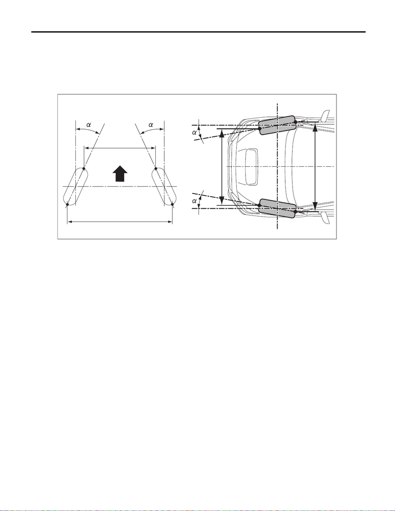

FS-3

General Description

FRONT SUSPENSION

NOTE:

• Front toe-in, rear toe-in and front camber can be adjusted. Adjust if the value of toe-in or camber exceeds

the tolerance range of the specification chart.

• Other items except for front toe-in, rear toe-in and front camber that are described in the specification chart

cannot be adjusted.

• If other items exceed the tolerance range of the specification chart, check the suspension parts and con-

nections for deformation. If defective, replace with new parts.

A – B = Positive: Toe-in, Negative: Toe-out

α

= Individual toe angles

A

B

FS-00657

B

A

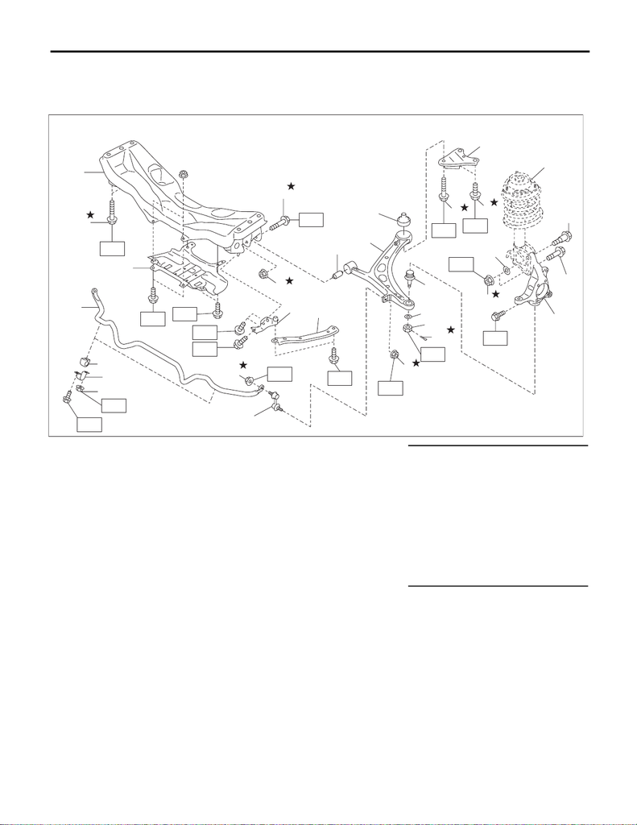

FS-4

General Description

FRONT SUSPENSION

B: COMPONENT

1. FRONT SUSPENSION

• Electric power steering model

(1) Front crossmember COMPL (14) Front arm ASSY Tightening torque: N·m (kgf-m, ft-lb)

(2) Flange bolt (15) Pillow ball bushing T1: 25 (2.5, 18.4)

(3) Self-locking nut (16) Flange bolt T2: 39 (4.0, 28.8)

(4) Support plate - front crossmember (17) Front arm rear plate T3: 50 (5.1, 36.9)

(5) Front support (18) Front strut ASSY T4: 60 (6.1, 44.3)

(6) Stabilizer link ASSY (19) Adjusting bolt T5: 95 (9.7, 70.1)

(7) Flange nut (20) Flange bolt T6: 100 (10.2, 73.8)

(8) Front crossmember support (21) Housing ASSY - front axle T7: 140 (14.3, 103.3)

(9) Bushing - stabilizer (22) Adjusting washer T8: 150 (15.3, 110.6)

(10) Clamp - stabilizer bushing (23) Ball joint ASSY T9: 155 (15.8, 114.3)

(11) Flange nut (24) Washer

(12) Front stabilizer (25) Castle nut

(13) Bushing front - front arm (26) Cotter pin

FS-00665

(2)

(1)

(9)

(12)

(8)

(10)

(7)

(7)

(11)

(7)

(3)

(2)

(2)

(6)

(17)

(5)

T3

T8

T9

T1

T1

T4

T4

T4

T6

T4

T4

T5

(4)

(13)

(22)

(21)

(20)

T4

(19)

(18)

T5

(15)

(16)

(23)

T7

(24)

(26)

T2

(14)

(25)

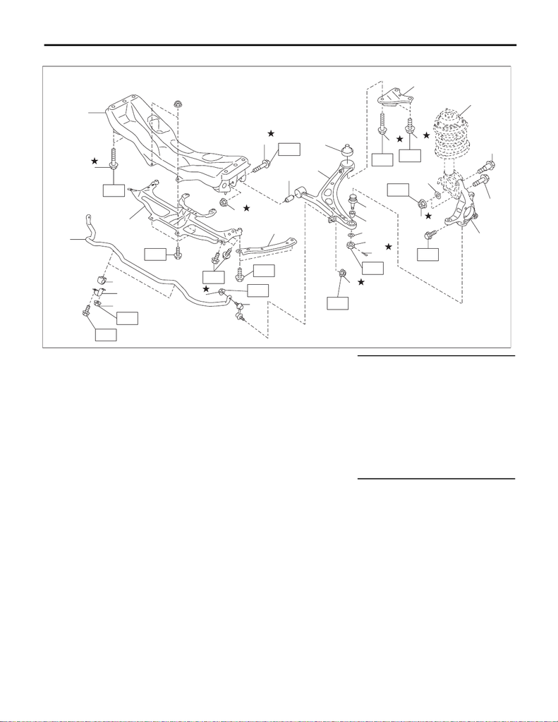

FS-5

General Description

FRONT SUSPENSION

• Hydraulic power steering model

(1) Front crossmember COMPL (14) Pillow ball bushing Tightening torque: N·m (kgf-m, ft-lb)

(2) Flange bolt (15) Flange bolt T1: 25 (2.5, 18.4)

(3) Self-locking nut (16) Front arm rear plate T2: 39 (4.0, 28.8)

(4) Front support (17) Front strut ASSY T3: 50 (5.1, 36.9)

(5) Stabilizer link ASSY (18) Adjusting bolt T4: 60 (6.1, 44.3)

(6) Flange nut (19) Flange bolt T5: 95 (9.7, 70.1)

(7) Front crossmember support (20) Housing ASSY - front axle T6: 100 (10.2, 73.8)

(8) Bushing - stabilizer (21) Adjusting washer T7: 140 (14.3, 103.3)

(9) Clamp - stabilizer bushing (22) Ball joint ASSY T8: 150 (15.3, 110.6)

(10) Flange nut (23) Boss - transverse link T9: 155 (15.8, 114.3)

(11) Front stabilizer (24) Washer

(12) Bushing front - front arm (25) Castle nut

(13) Front arm ASSY (26) Cotter pin

FS-00666

(14)

(6)

(15)

(2)

(22)

(23)

T7

T8

(12)

(16)

(24)

(26)

T4

T2

(6)

T3

T9

(21)

(20)

(19)

(18)

(17)

(2)

(1)

(8)

(11)

(9)

(10)

(3)

(2)

T1

T1

(6)

T4

T4

T5

(13)

T5

(4)

(7)

T4

T6

(25)

(5)

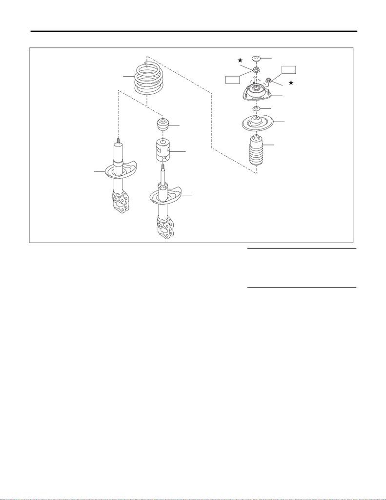

FS-6

General Description

FRONT SUSPENSION

2. FRONT STRUT

(1) Dust seal - front strut (7) Coil spring - front Tightening torque: N·m (kgf-m, ft-lb)

(2) Self-locking nut (8) Helper - front strut (standard

damper)

T1: 20 (2.0, 14.8)

(3) Strut mount - front (9) Dust cover inner (standard

damper)

T2: 55 (5.6, 40.6)

(4) Spacer - front strut (10) Strut COMPL - front (standard

damper)

(5) Spring seat - front strut UPR (11) Strut COMPL - front (inverted

damper)

(6) Dust cover - front strut

FS-00664

(1)

(3)

(2)

(10)

T2

(5)

(4)

T1

(6)

(7)

(9)

(8)

(2)

(11)

[figure not shown]

FS-7

General Description

FRONT SUSPENSION

C: CAUTION

• When performing any work, always wear work clothes, a work cap and protective shoes. Additionally, wear

a helmet, protective goggles, etc. if necessary.

• When disposing of strut COMPL - front, be sure to bleed the oil or gas out completely. Also, do not expose

to flames or fire.

• When performing a repair, identify the cause of trouble and avoid unnecessary removal, disassembly and

replacement.

• Use SUBARU genuine grease, the recommended or equivalent. Do not mix grease etc. of different grades

or manufacturers.

• Do not secure a part in a vise directly. Place cushioning materials such as wood pieces, blocks, aluminum

plates, or waste cloth between the part and the vise.

• Be sure to tighten fasteners including bolts and nuts to the specified torque.

• Always use the jack-up point when the shop jacks or rigid racks are used to support the vehicle.

• When the suspension-related components have been removed/installed or replaced, perform “VDC sen-

sor midpoint setting mode” of the VDC. <Ref. to VDC-16, VDC SENSOR MIDPOINT SETTING MODE, AD-

JUSTMENT, VDC Control Module and Hydraulic Control Unit (VDCCM&H/U).>

• For parts which are not reusable, always use new parts. Other parts should be replaced with new parts as

required.

• When handling oil or fuel, adhere to the following to prevent unexpected accident.

– Be careful with fire.

– Prepare a container to catch grease or oil, etc. If any grease or oil spills, wipe it off and clean immedi-

ately to prevent from penetrating into floor or flowing outside.

– Follow all government and local regulations concerning disposal of refuse when disposing.

• Be sure that the surface of brake disc or brake pad is free from grease or oil.

• Before disconnecting connectors of sensors or units, be sure to disconnect the ground cable from battery.

• Some vehicle components are extremely hot immediately after driving. Be wary of receiving burns from

heated parts.

[figure not shown]

FS-8

General Description

FRONT SUSPENSION

D: PREPARATION TOOL

1. SPECIAL TOOL

ILLUSTRATION TOOL NUMBER DESCRIPTION REMARKS

927680000 INSTALLER &

REMOVER SET

Used for replacing the bushing front - front arm

of front arm assembly.

20099AE020 INSTALLER &

REMOVER

Used for replacing pillow ball bushing of alumi-

num front arm.

28099PA010 HOUSING STAND • Used for removing pillow ball bushing of alumi-

num front arm.

• Used together with INSTALLER & REMOVER

(20099AE020).

18723AA000 REMOVER • Used for assembling pillow ball bushing of alu-

minum front arm.

• Used together with INSTALLER & REMOVER

(20099AE020).

ST-927680000

ST20099AE020

ST28099PA010

ST18723AA000

[figure not shown]

FS-9

General Description

FRONT SUSPENSION

2. GENERAL TOOL

20299AG020 STUD BOLT

SOCKET

Used for removing and installing the stud bolt for

front arm assembly installing portion.

20399AG000 STRUT MOUNT

SOCKET

• Used for disassembling and assembling strut

assembly and shock absorber assembly.

• Used for checking center nut torque of strut

assembly and shock absorber assembly.

TOOL NAME REMARKS

Alignment gauge Used for measuring wheel alignment.

Alignment gauge adapter Used for measuring wheel alignment.

Turning radius gauge Used for measuring wheel alignment.

Toe-in gauge Used for toe-in measurement.

Tie-rod ball joint puller Used for disconnecting tie-rod end.

Dial gauge Used for damper strut measurement.

Coil spring compressor Used for disassembling and assembling strut assembly and shock absorber assembly.

Shackle • Two units used for hanging power unit.

• Attached to both end of chain sling and connected to engine hook.

• Load capacity: 250 kg (551 lb) or more

Sling belt • Used for removing and installing crossmembers.

• Width: 35 — 40 mm (1.38 — 1.57 in)

• Length: 2 m (6.6 ft)

• Load capacity: 1 t (2205 lb) or more

ILLUSTRATION TOOL NUMBER DESCRIPTION REMARKS

ST20299AG020

ST20399AG000

[figure not shown]

FS-10

Wheel Alignment

FRONT SUSPENSION

2. Wheel Alignment

A: INSPECTION

Check the following items before performing the wheel alignment measurement.

• Tire inflation pressure

• Uneven wear of RH and LH tires, or difference of sizes

• Tire runout

• Excessive play and wear of ball joint

• Excessive play and wear of tie-rod end

• Excessive play of wheel bearing

• Right and left wheel base imbalance

• Deformation and excessive play of steering link

• Deformation and excessive play of suspension parts

Check, adjust and measure the wheel alignment in accordance with the following procedures.

1

Wheel arch height

(front and rear wheels)

Inspection: <Ref. to FS-11, WHEEL ARCH HEIGHT, INSPECTION, Wheel Alignment.>

↓

2

Camber

(front and rear wheels)

Inspection: <Ref. to FS-12, CAMBER, INSPECTION, Wheel Alignment.>

Adjustment: <Ref. to FS-15, FRONT CAMBER, ADJUSTMENT, Wheel Alignment.>

↓

3 Caster (front wheel) Inspection: <Ref. to FS-12, CASTER, INSPECTION, Wheel Alignment.>

↓

4 Steering angle

Inspection: <Ref. to FS-13, STEERING ANGLE, INSPECTION, Wheel Alignment.>

Adjustment: <Ref. to FS-17, STEERING ANGLE, ADJUSTMENT, Wheel Alignment.>

↓

5 Front wheel toe-in

Inspection: <Ref. to FS-13, FRONT WHEEL TOE-IN, INSPECTION, Wheel Alignment.>

Adjustment: <Ref. to FS-17, FRONT WHEEL TOE-IN, ADJUSTMENT, Wheel Alignment.>

↓

6 Rear wheel toe-in

Adjustment: <Ref. to FS-18, REAR WHEEL TOE-IN, ADJUSTMENT, Wheel Alignment.>

↓

7 Thrust angle

Inspection: <Ref. to FS-14, THRUST ANGLE, INSPECTION, Wheel Alignment.>

Adjustment: <Ref. to FS-20, THRUST ANGLE, ADJUSTMENT, Wheel Alignment.>